> Questão 1

Calcule os coeficientes da DFT para a sequência x(n) = {-1, 1, 2, -2}. Utilize a definição básica da DFT para realizar o cálculo.

```r
# Sequência de entrada x(n)
x <- c(-1, 1, 2, -2)

# Tamanho da sequência (N = 4)
N <- length(x)

# Vetor para armazenar o resultado X(k)
X_definicao <- numeric(N) + 0i

# Cálculo da DFT usando a definição:
for (k in 0:(N-1)) {
  soma <- 0 + 0i
  for (n in 0:(N-1)) {
    soma <- soma + x[n+1] * exp(-1i * 2 * pi * k * n / N)
  }
  X_definicao[k+1] <- soma
}

# Mostrando o resultado "manual"
cat("DFT calculada pela definição:\n")
```

```
## DFT calculada pela definição:
```

```r
print(X_definicao)
```

```
## [1]  0+0.000000e+00i -3-3.000000e+00i  2+1.102146e-15i -3+3.000000e+00i
```

> Questão 2

Calcule a matriz de rotação de fatores, W, para a sequência x(n) = {-1, 1, 2, -2}. Calcule os coeficientes da DFT e da IDFT baseado nesta matriz.

```r
# Definição do sinal de entrada

x <- c(-1, 1, 2, -2)
N <- length(x)

# 2) Construção da matriz W
W <- matrix(
  c(1, 1, 1, 1,
    1, -1i, -1, 1i,
    1, -1, 1, -1,
    1, 1i, -1, -1i),
  nrow = 4,
  ncol = 4,
  byrow = TRUE)

print(W)
```

```
##      [,1]  [,2]  [,3]  [,4]
## [1,] 1+0i  1+0i  1+0i  1+0i
## [2,] 1+0i  0-1i -1+0i  0+1i
## [3,] 1+0i -1+0i  1+0i -1+0i
## [4,] 1+0i  0+1i -1+0i  0-1i
```

```r
X <- W %*% x # Coef. da DFT

print(X)
```

```
##       [,1]
## [1,]  0+0i
## [2,] -3-3i
## [3,]  2+0i
## [4,] -3+3i
```

```r
INV <- (1/N) * Conj(W)
print(INV)
```

```
##         [,1]        [,2]     [,3]        [,4]
## [1,] 0.25+0i  0.25+0.00i  0.25+0i  0.25+0.00i
## [2,] 0.25+0i  0.00+0.25i -0.25+0i  0.00-0.25i
## [3,] 0.25+0i -0.25+0.00i  0.25+0i -0.25+0.00i
## [4,] 0.25+0i  0.00-0.25i -0.25+0i  0.00+0.25i
```

```r
x <- INV %*% X # Inversa de DFT

print(x)
```

```
##       [,1]
## [1,] -1+0i
## [2,]  1+0i
## [3,]  2+0i
## [4,] -2+0i
```

> Questão 3

Assumindo a sequência de x(n) = {-1, 1, 2, -2} foi amostrada a fs = 33Hz, qual a resolução em frequência da DFT?

```r
x <- c(-1, 1, 2, -2)
fs <- 33
N <- length(x)
resolucao_freq <- fs / N
resolucao_freq  # 8.25 Hz
```

```
## [1] 8.25
```

> Questão 4

```r
library(dygraphs)

f <- 20
fs <- 500
dt <- 1/fs
t <- seq(from = 0, to = 5, by = dt)
y <- sin(2*pi*f*t)

sinal <- data.frame(x = t, y = y)

dygraph(sinal, main = "Sinal senoidal") %>%
  dyRangeSelector()
```

[interactive chart not shown]

```r
N <- length(y)

delta <- fs/N # Resolução em frequencia

fn <- (length(y)-1)*delta # Frequencia para a n-ésima amostra do sinal

ff <- seq(from = 0, to = fn, by = delta) # Vetor de frequencia

y_fft <- fft(y) # FFT do sinal

# Plotagem do espectro de amplitude

mag <- Mod(y_fft) # Amplitude

dygraph(data.frame(x = ff, y = mag), main = "Espectro de amplitude",
        xlab = "Frequencia (Hz)",
        ylab = "Amplitude") %>%
  dyRangeSelector() %>%
  dyEvent(fs/2, label = "Simetria", labelLoc = "top")
```

[interactive chart not shown]

```r
# Espectro de fae

teta <- atan2(Im(y_fft), Re(y_fft)) # Fase

dygraph(data.frame(x = ff, y = teta), main = "Espectro de fase",
        xlab = "Frequencia (Hz)",
        ylab = "Fase") %>%
  dyRangeSelector() %>%
  dyEvent(fs/2, label = "Simetria", labelLoc = "top")
```

[interactive chart not shown]

> Questão 5

Explique o que é ordenação bit-reversa e forneça um exemplo de aplicação da mesma sobre a sequência de caracteres hojeodiaestabelo. Qual a sequência resultante?

É o reordenamento dos elementos de um vetor de tamanho N = 2^m de acordo com a inversão dos bits dos seus índices. Em outras palavras, se um elemento originalmente está na posição (índice) i, nós pegamos a representação binária de i (com m bits), invertemos a ordem desses bits e obtemos assim o “novo índice” onde esse elemento será colocado.

Por exemplo:

```r
library(kableExtra)
sequencia <- c("h", "o", "j", "e", "o", "d", "i", "a", "e", "s", "t", "a", "b", "e", "l", "o")

k_decimal <- seq(1:length(sequencia))

k_binario <- c("0000", "0001", "0010", "0011", "0100", "0101", "0110", "0111", "1000", "1001", "1010", "1011", "1100", "1101", "1110", "1111")

k_inverso <- c("0000", "1000", "0100", "1100", "0010", "1010", "0110", "1110", "0001", "1001", "0101", "1101", "0011", "1011", "0111", "1111")

# Criando sequência ordenada com base nos identificadores binários para cada algarismo

sequencia_ordenada <- c("h", "e", "o", "b", "j", "t", "i", "l", "o", "s", "d", "e", "e", "a", "a", "o")

seqs <- data.frame(sequencia, k_decimal, k_binario, k_inverso, sequencia_ordenada)

colnames(seqs) <- c("Sequência", "k_decimal", "k_binario", "k_reverso", "Sequência ordenada")

kable_styling(kable(t(seqs)), full_width = FALSE, bootstrap_option = "striped")
```

| Sequência | h | o | j | e | o | d | i | a | e | s | t | a | b | e | l | o |
| --- | --- | --- | --- | --- | --- | --- | --- | --- | --- | --- | --- | --- | --- | --- | --- | --- |
| k_decimal | 1 | 2 | 3 | 4 | 5 | 6 | 7 | 8 | 9 | 10 | 11 | 12 | 13 | 14 | 15 | 16 |
| k_binario | 0000 | 0001 | 0010 | 0011 | 0100 | 0101 | 0110 | 0111 | 1000 | 1001 | 1010 | 1011 | 1100 | 1101 | 1110 | 1111 |
| k_reverso | 0000 | 1000 | 0100 | 1100 | 0010 | 1010 | 0110 | 1110 | 0001 | 1001 | 0101 | 1101 | 0011 | 1011 | 0111 | 1111 |
| Sequência ordenada | h | e | o | b | j | t | i | l | o | s | d | e | e | a | a | o |

> Questão 6

Desenhe um diagrama de butterfly para 16 amostras. Apresente as equações de cada saída X(k). Qual o ganho em velocidade da FFT quando comparado à DFT neste exemplo?

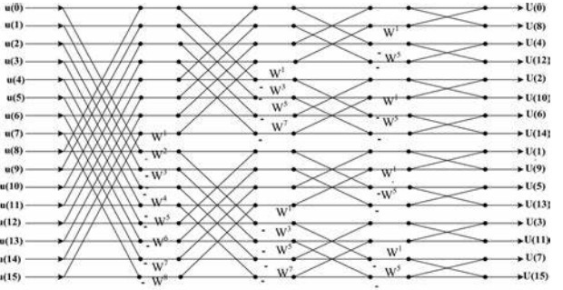

```r
knitr::include_graphics("C:/Users/heito/Documents/GitHub/PSB/Módulo 9 - PSB/Questao 6.jpg")
```

> Questão 7

No ambiente do R, leia o help da função fft (package: stats). Neste help existe uma implementação da DTF. Estude e comente os códigos apresentados no exemplo. Execute o exemplo, utilizando o sinal de entrada Z, e calculando os coeficientes da DFT por meio da equação geral e por meio da DFT. Utilize o trecho de código abaixo para calcular a diferença temporal entre a DFT e a FFT.

```r
x <- 1:4 # Cria um vetor de amostrar
fft(x)
```

```
## [1] 10+0i -2+2i -2+0i -2-2i
```

```r
ptm <- proc.time()
proc.time() - ptm
```

```
##   usuário   sistema decorrido
##         0         0         0
```

```r
fft(fft(x), inverse = TRUE/length(x))
```

```
## [1]  4+0i  8+0i 12+0i 16+0i
```

```r
# DFT

fft0 <- function(z, inverse = FALSE) {
  n <- length(z)
  if(n == 0)
    return(z)
  k <- 0:(n-1)
  ff <- (if(inverse) 1 else -1) * 2 * pi * 1i * k/n
  vapply(1:n, function(h) sum(z * exp(ff*(h-1))), complex(1))
}

relD <- function(x, y) 2 * abs(x - y) / abs (x + y)
n <- 2^8 # N elementos

set.seed(1234)
z <- complex(n, rnorm(n), rnorm(n)) # Coef. Complexos

summary(relD(fft(z), fft0(z)))
```

```
##      Min.   1st Qu.    Median      Mean   3rd Qu.      Max.
## 2.594e-16 1.433e-14 3.274e-14 4.953e-14 6.440e-14 4.308e-13
```

```r
summary(relD(fft(z, inverse = TRUE), fft0(z, inverse = TRUE)))
```

```
##      Min.   1st Qu.    Median      Mean   3rd Qu.      Max.
## 0.000e+00 1.435e-14 3.196e-14 5.451e-14 6.771e-14 3.728e-13
```

```r
ptm <- proc.time()
fft(z)
```

```
##   [1]   0.08585092+ 0.1394106i -12.03875981+36.8176944i -13.15680246+23.6945613i
##   [4]  16.18658635+14.4382614i  -3.31652910- 2.1932568i  -3.17405619-20.8429751i
##   [7]  -2.17668166-21.4323458i   2.17828220+13.6019413i  18.12908858+10.7460209i
##  [10] -27.04321047- 7.2313370i  -6.59912384+24.9650708i  -5.59174230-13.2357966i
##  [13] -20.39598905+34.6633245i -10.95483158-11.5945363i   4.96332973- 6.1278450i
##  [16]   5.88519058+ 4.9779260i  17.63472132- 7.0476338i  -0.89367505+10.8886979i
##  [19]  22.71821720+17.9506666i  11.46011779-27.6312076i  -2.85924271+16.1522819i
##  [22]  -1.21870221+ 8.3041441i -12.21194192-11.8664959i   2.88586206-10.5361126i
##  [25]  -3.79402870+12.7764515i  -1.70822903-11.3705326i  10.53479732+12.3655086i
##  [28] -31.61006634-11.5833622i   2.83581578-50.4451099i   8.80032566- 9.0237152i
##  [31]   8.68059301+33.6264169i -16.76245167- 6.3342277i  -4.52355917-12.6078101i
##  [34]  28.63378649+17.9045893i  -5.39536275- 2.1176998i   2.89407007+ 7.2989105i
##  [37]   2.53124213+11.2990515i -17.68353632+14.3892349i -18.14570115+19.8892927i
##  [40]   5.63294500-13.5487753i -28.91448129-27.9810160i   4.17942521-25.9243166i
##  [43]  42.92958549-39.4269638i -13.29698420- 7.4373448i -23.48368939- 1.2798930i
```

[output cut: 71 more lines]

```r
proc.time() - ptm
```

```
##   usuário   sistema decorrido
##      0.03      0.00      0.03
```

```r
ptm <- proc.time()
fft0(z)
```

```
##   [1]   0.08585092+ 0.1394106i -12.03875981+36.8176944i -13.15680246+23.6945613i
##   [4]  16.18658635+14.4382614i  -3.31652910- 2.1932568i  -3.17405619-20.8429751i
##   [7]  -2.17668166-21.4323458i   2.17828220+13.6019413i  18.12908858+10.7460209i
##  [10] -27.04321047- 7.2313370i  -6.59912384+24.9650708i  -5.59174230-13.2357966i
##  [13] -20.39598905+34.6633245i -10.95483158-11.5945363i   4.96332973- 6.1278450i
##  [16]   5.88519058+ 4.9779260i  17.63472132- 7.0476338i  -0.89367505+10.8886979i
##  [19]  22.71821720+17.9506666i  11.46011779-27.6312076i  -2.85924271+16.1522819i
##  [22]  -1.21870221+ 8.3041441i -12.21194192-11.8664959i   2.88586206-10.5361126i
##  [25]  -3.79402870+12.7764515i  -1.70822903-11.3705326i  10.53479732+12.3655086i
##  [28] -31.61006634-11.5833622i   2.83581578-50.4451099i   8.80032566- 9.0237152i
##  [31]   8.68059301+33.6264169i -16.76245167- 6.3342277i  -4.52355917-12.6078101i
##  [34]  28.63378649+17.9045893i  -5.39536275- 2.1176998i   2.89407007+ 7.2989105i
##  [37]   2.53124213+11.2990515i -17.68353632+14.3892349i -18.14570115+19.8892927i
##  [40]   5.63294500-13.5487753i -28.91448129-27.9810160i   4.17942521-25.9243166i
##  [43]  42.92958549-39.4269638i -13.29698420- 7.4373448i -23.48368939- 1.2798930i
```

[output cut: 71 more lines]

```r
proc.time() - ptm
```

```
##   usuário   sistema decorrido
##      0.05      0.00      0.10
```

> Questão 8

Gere um sinal y, formado pela adição de três componentes senoidais, de amplitude unitária, e oscilando a 10, 23 e 49 Hz. Adicione um ruído gaussiano ao sinal y, cuja amplitude máxima é no máximo 10% o valor máximo do sinal. Calcule, por meio do uso da função fft, o espectro de amplitude e fase para o sinal resultante. Adote a frequência de amostragem de 700 Hz, e a duração total do sinal de 10 segundos.

```r
fs <- 700 # Frequencia de amostragem
dt <- 1/fs # Incremento
f1 <- 10 # Frequencia y1
f2 <- 23 # Frequencia y2
f3 <- 49 # Frequencia y3
t <- seq(from = 0, to = 10, by = dt) # Vetor de tempo

y1 <- sin(2*pi*f1*t) # Seno 1
y2 <- sin(2*pi*f2*t) # Seno 2
y3 <- sin(2*pi*f3*t) # Seno 3

y <- y1 + y2 +y3

# Plotagem
dygraph(data.frame(x = t, y = y), main = "Sinal sem ruído") %>%
  dyRangeSelector()
```

[interactive chart not shown]

```r
set.seed(1010)
y <- y + 0.1*max(y)*rnorm(length(t)) # Ruído

# Plotagem

dygraph(data.frame(x = t, y = y), main = "Sinal com ruído") %>%
  dyRangeSelector()
```

[interactive chart not shown]

```r
N <- length(y)
delta <- fs/N # Resolução da frequencia

fn <- (length(y)-1)*delta # Frequencia para a n-ésina amostra
ff <- seq(from = 0, to = fn, by = delta) # Vetor de frequencia

y_fft <- fft(y) # FFT do sinal gerado

# Espectro de amplitude

mag <- Mod(y_fft) # Amplitude

dygraph(data.frame(x = ff, y = mag), main = "Espectro de amplitude",
        xlab = "Frequencia (Hz)",
        ylab = "Amplitude") %>%
  dyRangeSelector() %>%
  dyEvent(fs/2, label = "Simetria", labelLoc = "top")
```

[interactive chart not shown]

```r
# Espectro de fase

teta <- atan2(Im(y_fft), Re(y_fft)) # Fase

dygraph(data.frame(x = ff, y = teta), main = "Espectro de fase",
        xlab = "Frequencia (Hz)",
        ylab = "Fase") %>%
  dyRangeSelector() %>%
  dyEvent(fs/2, label = "Simetria", labelLoc = "top")
```

[interactive chart not shown]